# MaiaAnalysis

Maia Czerwonka

2024-02-27

```r
# Load in .csv
setwd("/Users/maia/Library/CloudStorage/OneDrive-UW/CCDL/MGH Research Project")

data <- read.csv("MaiaData_CardSort.csv")
```

## 0.1 Descriptives of Dataset

```r
data %>%
  select(-c(Subject, Sex)) %>%
  psych::describe()
```

```
##                vars   n   mean     sd median trimmed    mad     min     max
## Age               1 183  40.05  14.52  38.00   39.22  13.34   10.00   87.00
## IncorRespCount    2 185   1.83   3.12   1.00    1.13   1.48    0.00   19.00
## SymRespCount      3 185  18.10  17.66  12.00   16.96  16.31    0.00   48.00
## TxtRespCount      4 185  28.07  17.95  33.00   28.91  20.76    0.00   48.00
## BiasScore         5 185   0.21   0.76   0.44    0.25   0.77   -1.00    1.00
## Con_RT            6 185 885.79 174.50 866.42  875.88 160.51  529.08 1579.72
## InCon_RT          7 185 987.53 325.00 925.81  946.21 209.20  528.29 2863.08
## Incon.ConRT       8 185 101.74 239.42  46.57   62.58  74.70 -116.09 1902.28
##                  range  skew kurtosis    se
## Age              77.00  0.55     0.20  1.07
## IncorRespCount   19.00  3.35    11.70  0.23
## SymRespCount     48.00  0.45    -1.49  1.30
## TxtRespCount     48.00 -0.31    -1.61  1.32
## BiasScore         2.00 -0.38    -1.55  0.06
## Con_RT         1050.64  0.63     0.59 12.83
## InCon_RT       2334.79  2.91    13.12 23.89
## Incon.ConRT    2018.37  5.34    33.94 17.60
```

## 0.2 Distributions of Bias

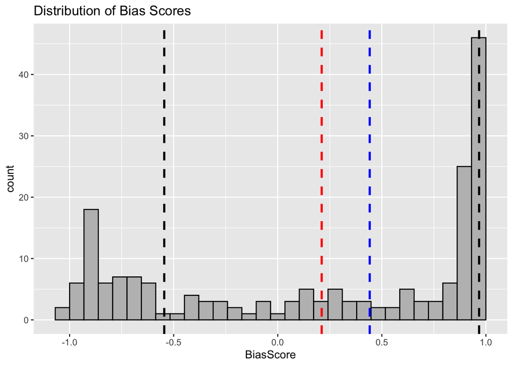

```r
biasMean <- mean(data$BiasScore, na.rm = T)
biasMedian <- median(data$BiasScore, na.rm = T)

bias1sd <- biasMean + sd(data$BiasScore)
biasneg1sd <- biasMean - sd(data$BiasScore)


data %>%
  ggplot(aes(x=BiasScore)) +
  geom_histogram(fill = "grey", color = "black") +
  geom_vline(mapping = aes(xintercept = biasMean), color = "red", linetype = "dashed", size = 1) +
  geom_vline(mapping = aes(xintercept = biasMedian), color = "blue", linetype = "dashed", size = 1) +
   geom_vline(mapping = aes(xintercept = bias1sd), color = "black", linetype = "dashed", size = 1) +
   geom_vline(mapping = aes(xintercept = biasneg1sd), color = "black", linetype = "dashed", size = 1) +
  ggtitle("Distribution of Bias Scores")
```

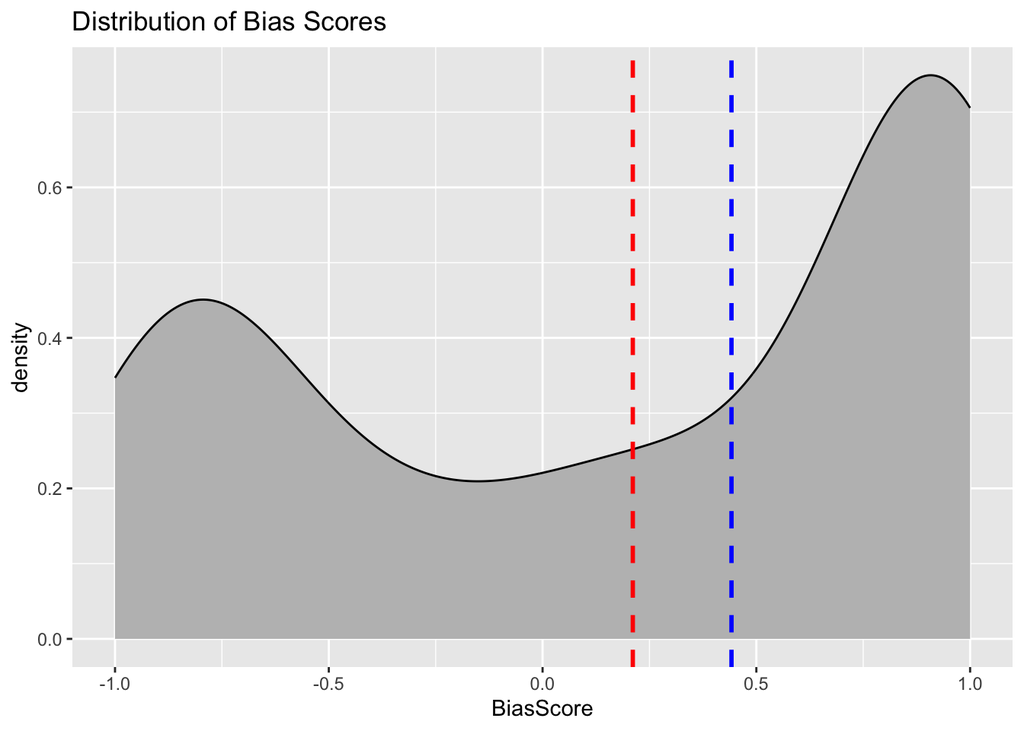

```r
data %>%
  ggplot(aes(x=BiasScore)) +
  geom_density(fill = "grey", color = "black") +
   geom_vline(mapping = aes(xintercept = biasMean), color = "red", linetype = "dashed", size = 1) +
  geom_vline(mapping = aes(xintercept = biasMedian), color = "blue", linetype = "dashed", size = 1) +
  ggtitle("Distribution of Bias Scores")
```

# A lot less neutral people than biased people

## 0.3 Distributions of Incongruency Effect - Whole Group & Bias Split

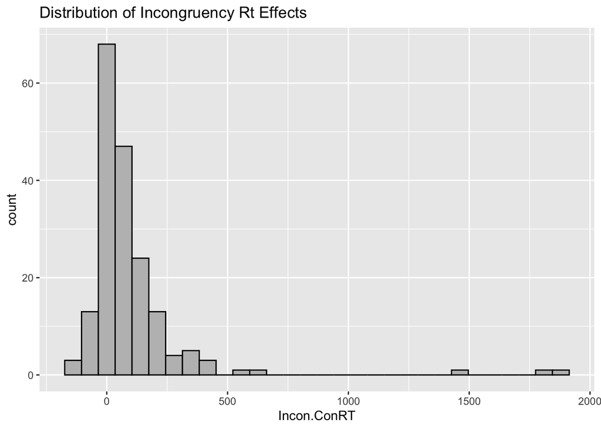

```r
# Whole group distribution of incongruency effect

data %>%
  ggplot(aes(x=Incon.ConRT)) +
  geom_histogram(fill = "grey", color = "black") +
  ggtitle("Distribution of Incongruency Rt Effects")
```

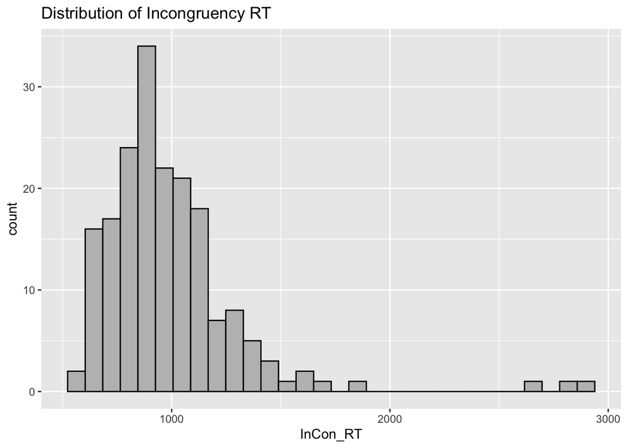

```r
data %>%
  ggplot(aes(x=InCon_RT)) +
  geom_histogram(fill = "grey", color = "black") +
  ggtitle("Distribution of Incongruency RT")
```

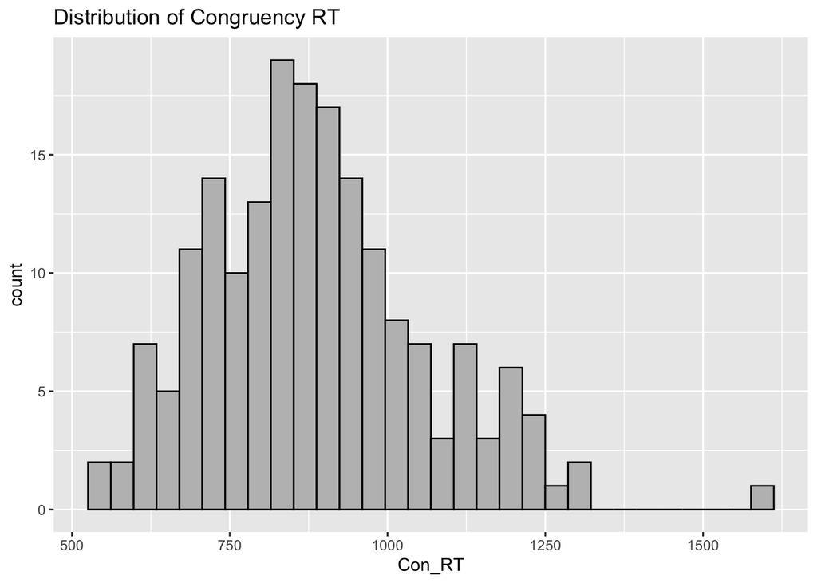

```r
data %>%
  ggplot(aes(x=Con_RT)) +
  geom_histogram(fill = "grey", color = "black") +
  ggtitle("Distribution of Congruency RT")
```

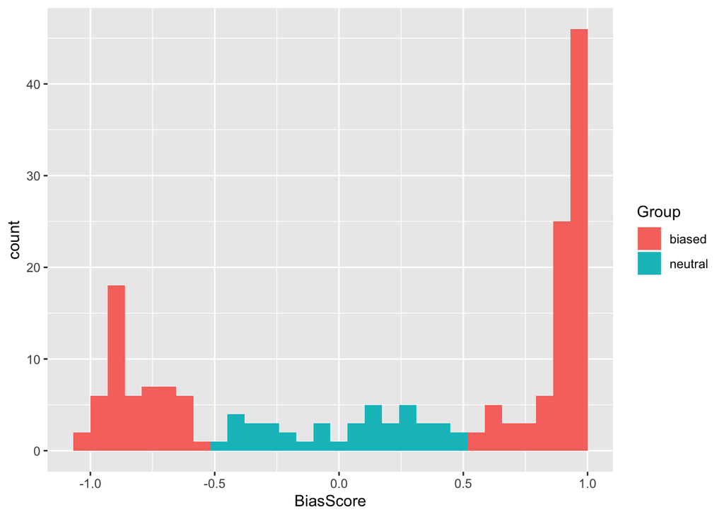

```r
# Split groups based on bias score
biased <- subset(data, data$BiasScore > 0.5 | data$BiasScore < -0.5)
neutral <- subset(data, data$BiasScore <= 0.5 & data$BiasScore >= -0.5)

biased$Group = "biased"
neutral$Group = "neutral"

data_grouped <- rbind(biased, neutral)

data_grouped %>%
  ggplot(aes(x = BiasScore, fill = Group))+
  geom_histogram()
```

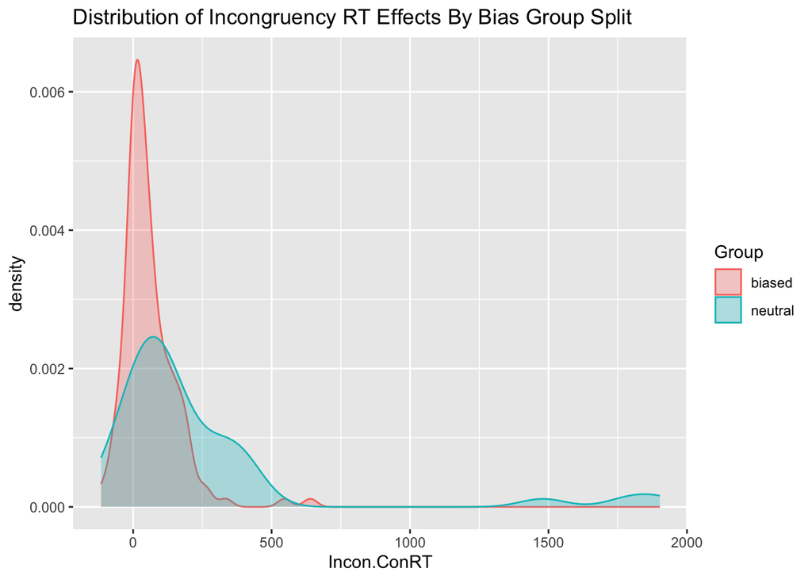

```r
data_grouped %>%
  ggplot(aes(x = Incon.ConRT, fill = Group, color = Group))+
  geom_density(alpha = 0.3)+
  ggtitle("Distribution of Incongruency RT Effects By Bias Group Split")
```

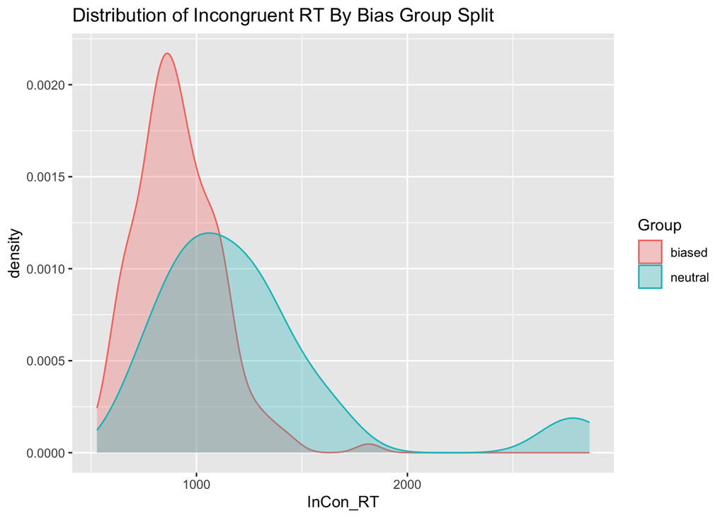

```r
data_grouped %>%
  ggplot(aes(x = InCon_RT, fill = Group, color = Group))+
  geom_density(alpha = 0.3)+
  ggtitle("Distribution of Incongruent RT By Bias Group Split")
```

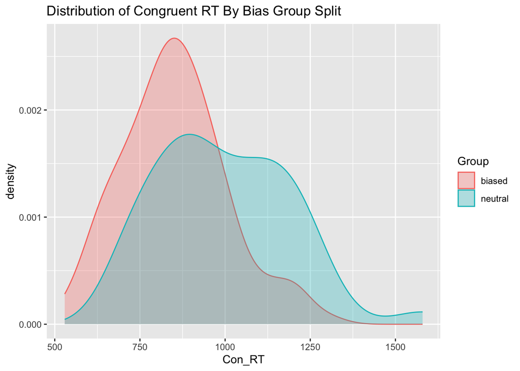

```r
data_grouped %>%
  ggplot(aes(x = Con_RT, fill = Group, color = Group))+
  geom_density(alpha = 0.3)+
  ggtitle("Distribution of Congruent RT By Bias Group Split")
```

# Incongruency RT Effect Dist: Most people have an incongruency effect of 0 or > so, as expected, incongruent trial reaction times are generally greater than congruent trial reaction times. Slight right skew that is made extreme by outliers- will reexamine with outliers removed. # Distribution of Incongruency Effect by Bias Group Split: There are more people who have a lower incongruency effect in the biased attender group than in the neutral attender group. Neutral attender group has a lot less people but its density is a lot more spread out while biased attender incongruency effect has a lot less range and is more concentrated near 0. # Congruent and Incongruent Distributions by Bias Group Split: Biased group seems to be taking less time than the neutral group in both trial types. Could be indication of biased attenders mainly paying attention to their preferred information processing style and ignoring the other stimulus so RTs are faster in both trial types.

## 0.4 Bar plot of reaction times by trial type and attention

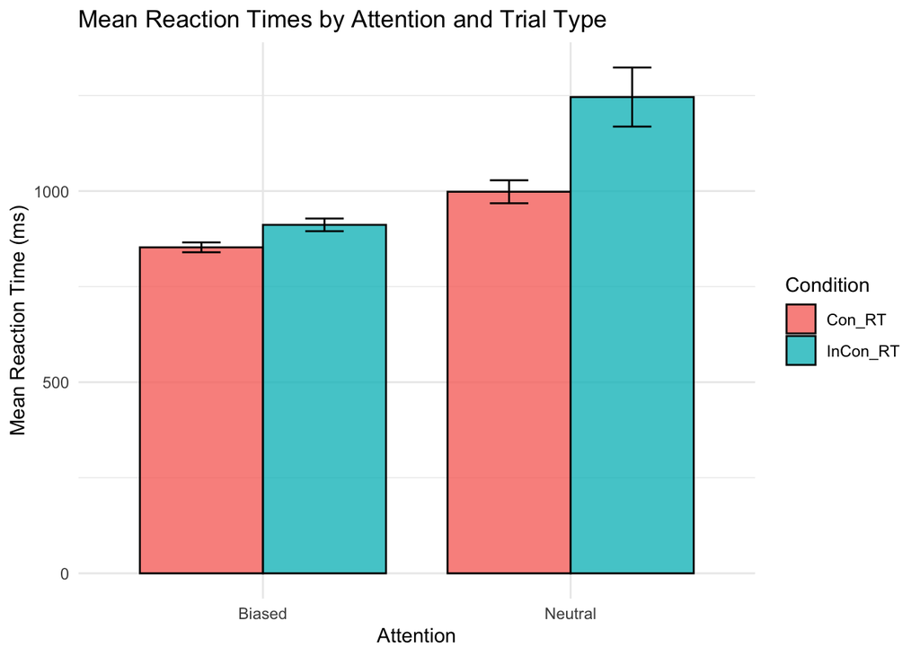

```r
# Load necessary libraries
library(tidyverse)
library(ggplot2)
library(reshape2)

data$Attention <- ifelse(data$BiasScore > 0.5 | data$BiasScore < -0.5, "Biased", "Neutral")
data$IPS <- ifelse(data$BiasScore > 0, "Verbal", "Visual")

#Reaction times
#Biased attender histograms and descriptive statistics
biased_data<- data[data$Attention == "Biased", ]
neutral_data<- data[data$Attention == "Neutral", ]

# Combine biased and neutral data
data$Attention <- ifelse(data$BiasScore > 0.5 | data$BiasScore < -0.5, "Biased", "Neutral")
biased_data<- data[data$Attention == "Biased", ]
combined_data <- rbind(biased_data, neutral_data)

# Calculate means by attention and trial type
means <- combined_data %>%
  group_by(Attention) %>%
  summarise(Con_RT = mean(Con_RT), InCon_RT = mean(InCon_RT)) %>%
  pivot_longer(cols = c(Con_RT, InCon_RT), names_to = "Trial_Type", values_to = "RT")

# Order factor levels for better plotting
means$Attention <- factor(means$Attention, levels = unique(means$Attention))

combined_long <- combined_data %>%
  select(Attention, InCon_RT, Con_RT) %>%
  pivot_longer(cols = c(InCon_RT, Con_RT), values_to = "RT", names_to = "Condition")

# Creat error bars
se_sum <- combined_long %>%
  group_by(Attention, Condition) %>%
  summarise(
    sd = sd(RT),
    n = n(),
    mean = mean(RT)
  ) %>%
  mutate(se = sd/sqrt(n))
# Create bar plot

ggplot(se_sum, aes(x = Attention, y = mean, fill = Condition)) +
  geom_bar(position = position_dodge(0.8), stat = "identity", color = "black", size = 0.5, width = 0.8, alpha = 0.8) +
  geom_errorbar(aes(ymin = mean - se, ymax = mean + se), position = position_dodge(0.8), width = 0.25, color = "black") +
  labs(title = "Mean Reaction Times by Attention and Trial Type",
       x = "Attention",
       y = "Mean Reaction Time (ms)") +
  theme_minimal()
```

#incon rts are larger overall, but the difference between incon and con trial rts for the biased group is a lot smaller than the neutral group- perhaps because the neutral group is noticing both stimuli more? #figure out how to put error bars

## 0.5 Incongruency Effect Descriptives

```r
# Incongruency Effect Calculation
data$IncongruencyEffect <- data$InCon_RT - data$Con_RT
Incongruency_Effect_Data <- data$IncongruencyEffect

biased_data$Incongruency_Effect_Data <- biased_data$InCon_RT - biased_data$Con_RT
neutral_data$Incongruency_Effect_Data <- neutral_data$InCon_RT - neutral_data$Con_RT
```

### 0.5.1 Biased group descriptives

```r
psych::describe(biased_data$Incongruency_Effect_Data)
```

```
##    vars   n  mean     sd median trimmed  mad     min    max  range skew
## X1    1 143 58.84 100.78  33.69   47.64 62.2 -114.36 640.06 754.42 2.38
##    kurtosis   se
## X1     9.82 8.43
```

### 0.5.2 Neutral group descriptives

```r
psych::describe(neutral_data$Incongruency_Effect_Data)
```

```
##    vars  n   mean     sd median trimmed    mad     min     max   range skew
## X1    1 42 247.78 440.23  97.56  149.04 131.32 -116.09 1902.28 2018.37 2.74
##    kurtosis    se
## X1     6.85 67.93
```

```r
# Biased Attender Incongruency Effect Descriptive Statistics
biased_IE_mean <- mean(biased_data$Incongruency_Effect_Data)
biased_IE_std <- sd(biased_data$Incongruency_Effect_Data)
biased_IE_min <- min(biased_data$Incongruency_Effect_Data)
biased_IE_max <- max(biased_data$Incongruency_Effect_Data)

# Data frame for Biased Attender Incongruency Effect Descriptive Statistics
biased_descriptive_IE <- data.frame(
  Attention = "Biased",
  Variable = "Incongruency Effect",
  Mean = biased_IE_mean,
  StdDev = biased_IE_std,
  Min = biased_IE_min,
  Max = biased_IE_max,
  stringsAsFactors = FALSE
)

# Neutral Attender Incongruency Effect Descriptive Statistics
neutral_IE_mean <- mean(neutral_data$Incongruency_Effect_Data)
neutral_IE_std <- sd(neutral_data$Incongruency_Effect_Data)
neutral_IE_min <- min(neutral_data$Incongruency_Effect_Data)
neutral_IE_max <- max(neutral_data$Incongruency_Effect_Data)

# Data frame for Neutral Attender Incongruency Effect Descriptive Statistics
neutral_descriptive_IE <- data.frame(
  Attention = "Neutral",
  Variable = "Incongruency Effect",
  Mean = neutral_IE_mean,
  StdDev = neutral_IE_std,
  Min = neutral_IE_min,
  Max = neutral_IE_max,
  stringsAsFactors = FALSE
)

descriptive_statistics_IE <- rbind(biased_descriptive_IE, neutral_descriptive_IE)
print(descriptive_statistics_IE)
```

```
##   Attention            Variable      Mean   StdDev       Min       Max
## 1    Biased Incongruency Effect  58.84309 100.7779 -114.3611  640.0625
## 2   Neutral Incongruency Effect 247.77513 440.2280 -116.0903 1902.2847
```

## 0.6 Incongruency Effect Box Plot

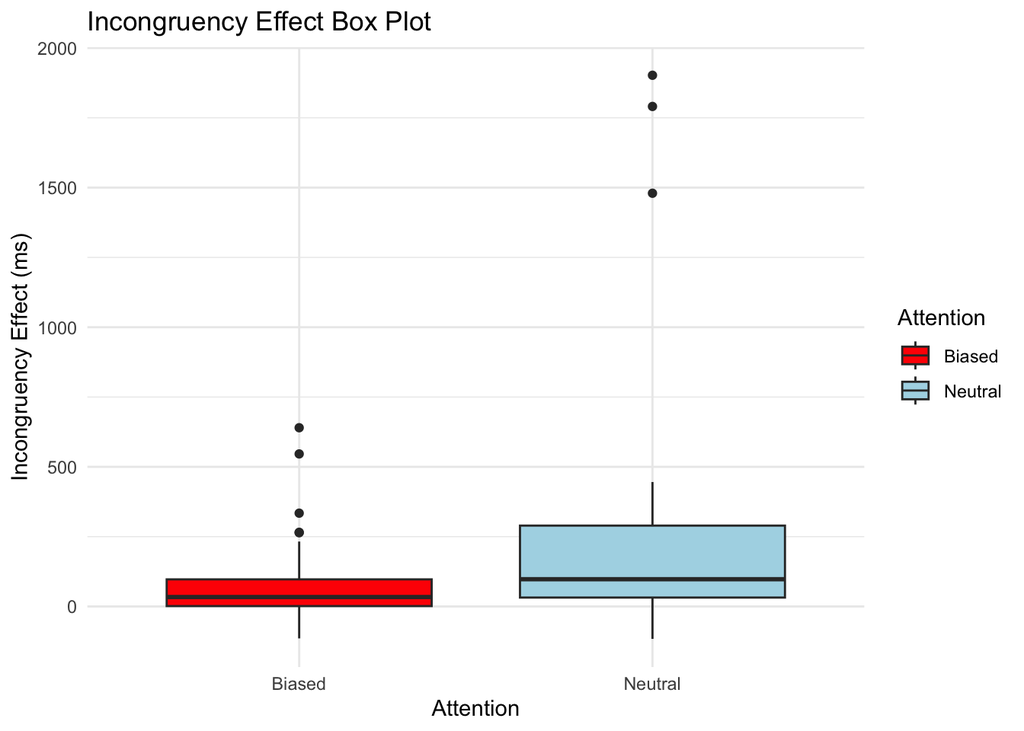

```r
# Load necessary libraries
library(ggplot2)

# Combine biased and neutral data for the box plot
combined_data <- rbind(biased_data, neutral_data)

# Create box plot
ggplot(combined_data, aes(x = Attention, y = Incongruency_Effect_Data, fill = Attention)) +
  geom_boxplot() +
  labs(
    title = "Incongruency Effect Box Plot",
    x = "Attention",
    y = "Incongruency Effect (ms)"
  ) +
  scale_fill_manual(values = c("red", "lightblue")) +  # Color for biased and neutral data
  theme_minimal()
```

## Incongruency Effect Scatter Plot

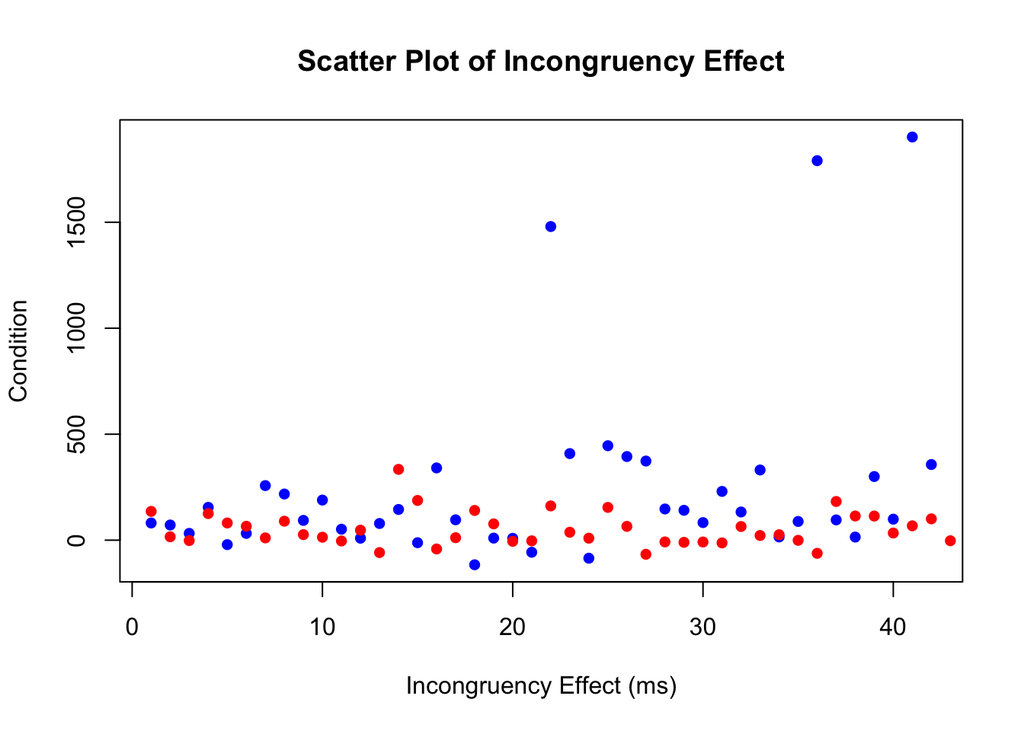

```r
# Scatter Plot of Incongruency Effect
plot(neutral_data$Incongruency_Effect_Data,
     col = "blue",
     pch = 16,
     main = "Scatter Plot of Incongruency Effect",
     xlab = "Incongruency Effect (ms)",
     ylab = "Condition")

# Adding Biased Attender Data Points
points(biased_data$Incongruency_Effect_Data,
       col = "red",
       pch = 16)
```

# 1 Individual differences Analysis

## 1.1 Correlate Bias score in whole group with incongruency RT effect

```r
cor.test(data$BiasScore, data$Incon.ConRT)
```

```
##
##  Pearson's product-moment correlation
##
## data:  data$BiasScore and data$Incon.ConRT
## t = -2.6908, df = 183, p-value = 0.007789
## alternative hypothesis: true correlation is not equal to 0
## 95 percent confidence interval:
##  -0.33006526 -0.05228936
## sample estimates:
##        cor
## -0.1950863
```

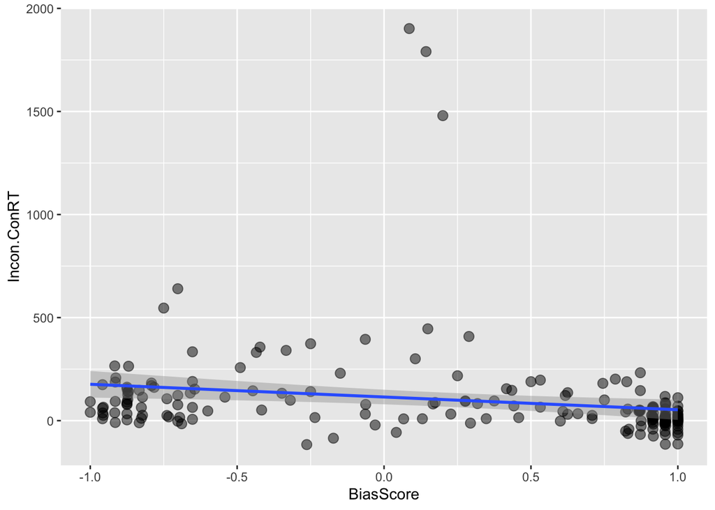

```r
data %>%
  ggplot(aes(x = BiasScore, y = Incon.ConRT)) +
  geom_point(size = 3, alpha = 0.5, fill = "grey") +
  geom_smooth(method = "lm")
```

#doesn’t look like much of a correlation, reexamine with outliers removed.